# E-commerce shipping data analysis Part 2

## Explanatory Analysis

## `Investigation Overview`

- In this investigation i want to reveal the patterns and trends in the data in order to help the E-commerce company make data driven decisions

## `Data Overview`

- The data contains different attributes related to an international E-commerce shipping company, it consists of 10999 observations and 12 variables including: Id number of customers, gender of customer, cost of the product, mode of shipment, and customer rating and others.
- Data Link on kaggle: https://www.kaggle.com/prachi13/customer-analytics?select=Train.csv

## Distribution of products prices

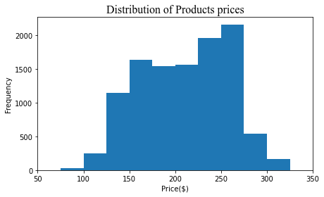

### The prices of products vary from 96 usd for the product to 310 usd, but the prices of products that have the highest sales records are between 225 usd and 275 usd

## Proportion of each gender in our customers

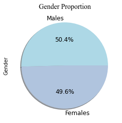

### Number of males is almost equal to number of females in our customers

## Which shipping method is commonly used ?

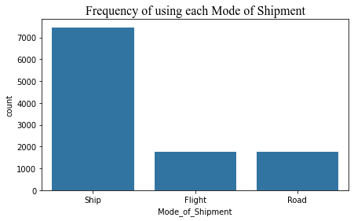

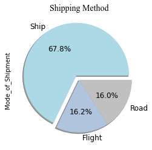

### The most frequent mode of shipping is ship, both flight and road has equal share.

## What is the shipping method that has the highest rate of delievering products on time ?

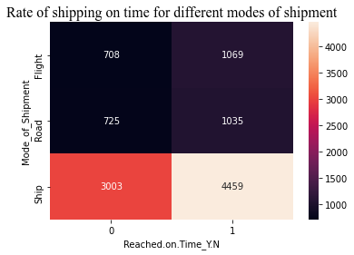

### Despite that ship is the most common used mode of shipment, it doesn't have the highest rate of delievering the products on time, but the differences between each mode of shipment is small, so maybe there is another reason behind using it, maybe it's cost of shipping is less than others, but we don't have data in this dataset to prove it

- Percentage of shipments that reached on time using Flight 60 %
- Percentage of shipments that reached on time using Ship 59.7 %
- Percentage of shipments that reached on time using Road 58.8 %

## What is the proportion of shippings that was delievered on time ?

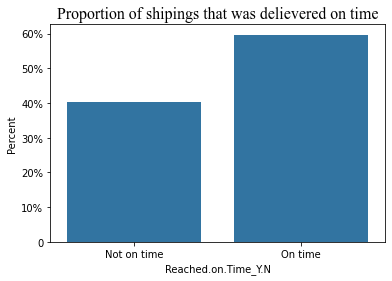

### 60% of the shipments were delieverd on time.

## What is the relationship between gender, product importance and discount offered ?

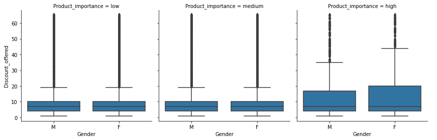

### Products with high importance tend to have higher discount, and in this product category women tend to have higher discounts than men

## In terms of product quality, which category has the highest sales count ?

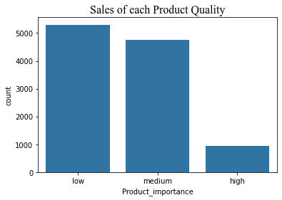

### Low quality products sell the most followed by medium quality and high quality products are far less than them in terms of sales

## In terms of product quality, which category has the highest sales ?

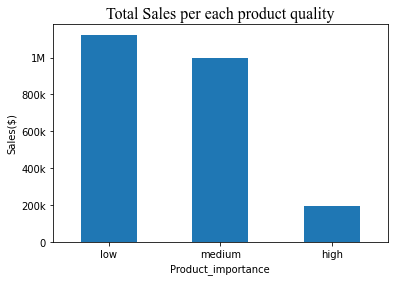

### Sales of low quality products exceed 1 Million usd, sales of medium quality products is almost 1 Million usd, while sales of high quality products are below 200k usd

## What is the relationship between product quality, gender and total sales ?

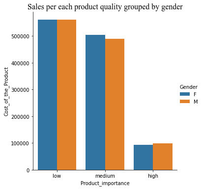

### Women buy more medium quality products than men and men buy more high quality products than women

## In terms of product quality, which category has the highest on time delievry rate ?

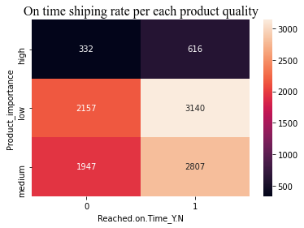

### High quality products have the highest on time shiping rate